# cool_notes_analytic

```python
from IPython.display import HTML

HTML('''<script>
code_show=true;
function code_toggle() {
 if (code_show){
 $('div.input').hide();
 } else {
 $('div.input').show();
 }
 code_show = !code_show
}
$( document ).ready(code_toggle);
</script>
<form action="javascript:code_toggle()"><input type="submit" value="Click here to toggle on/off the raw code."></form>''')
```

**Analytic notes on radiative cooling**

where r, n, v, and T are the radius, number density, fluid velocity and temperature respectively. q is the rate of mass injection (per unit volume), and $v_w$ is the velocity of the stellar winds.

We evaluate the critical density required for thermal instability for a few different regions in the parameter space.

**Cooling function**

For solar metallicity gas, the cooling function is approximately given by

$$\Lambda_c(T)= \begin{cases} 1.1\times 10^{-22} \left(\frac{T}{10^6 {\rm K}}\right)^{-0.7} {\rm erg\,\,cm^{3}\,\,s^{-1}} & T<2.5\times 10^7 {\rm K} \\ 2.3\times 10^{-24} \left(\frac{T}{10^6 {\rm K}}\right)^{0.5} {\rm erg\,\,cm^{3}\,\,s^{-1}} & T\geq 2.5\times 10^7 {\rm K} \\ \end{cases} $$

The top line corresponds to cooling from metal lines, while the bottom line corresponds to cooling from Bremsstrahlung. We only expect the latter to be relevant for $v_w \geq 1000$ km s$^{-1}$, or well inside of the stagnation radius. Unless otherwise specified, we assume metal line cooling.

**Case 1**

Consider the outflowing gas, well outside of the stagnation radius.

Assuming that the logarithmic slope of the stellar density profile, $d$, is between 1 and 3, the fluid velocity is given by

$v=v_w \sqrt{-\frac{(d-1)(\gamma-1)}{(\gamma d +d -5\gamma-1)}}$,

where $\gamma$ is the adiabatic index. For $\gamma=5/3$, the pre-factor (plotted below) is typically $\sim 0.5$.

The temperature in the outflow is given by

T=$1.8\times 10^7 {\rm K} v_{w, 500}^2 \sqrt{\frac{(d-3) (d-1)}{\gamma (\gamma d+d-5 \gamma-1)}},$

where $v_{w, 500}$ is the wind velocity normalized to 500 km s$^{-1}$. The conditions for thermal instability will be satisfied for

1. $n_{\rm crit} \sim 10^3 v_{w, 500}^{4.4} r_{18}^{-1}$ cm$^{-3}$
2. $n_{\rm crit} \sim 40 v_{w, 500}^{1.7} q_o^{0.5} r_{18}^{-\eta/2} $cm$^{-3},$

where $r_{18}$ is the radius in units of $10^{18}$ cm. $q_o$ is the is mass source function at 10$^{18}$ cm normalized to ($10^{-5} M_{\odot}$ yr$^{-1}$ pc$^{-3}$). In the absence of cooling the density profile on large scale is proportional to $r^{1-\eta}$. For $\eta<2$ the outflow *necessarily* becomes thermally unstable on large scales, if the mass source function is not truncated!

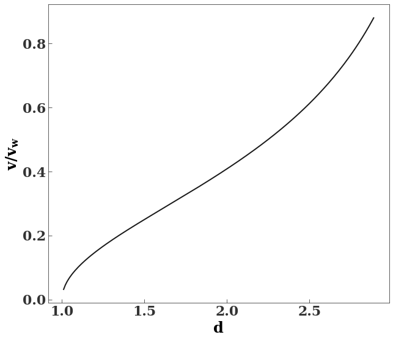

```python
%pylab inline

fig,ax=plt.subplots(figsize=(10,9))
ax.set_ylabel(r'$v/v_w$')
ax.set_xlabel('d')

ds=np.arange(1.01, 2.9, 0.01)
def pre1(gamma, d):
    return (-((d-1.)*(gamma-1.))/(gamma*d+d-5.*gamma-1.))**0.5

def pre2(gamma, d):
    return ((-3.+d)*(-1.+d)/(gamma*(-1.+d-5.*gamma+d*gamma)))**0.5

plot(etas, pre1(5./3., ds))
# plot(etas, pre2(5./3., ds))
```

**Case 2**

Consider a pure inflow well outside of the SMBH's sphere of influence. (This might correspod to a case in which heating is dominated by Ia supernovae and the effective stagnation radius is well outside of the influence radius).

In this case the inflow time is given by $r/\sigma$ (where $\sigma$ is approximately constant). The gas is heated to the virial temperature (so that $\sigma^2 \sim c_s^2$). Then, the cooling time is shorter than the inflow time for densities greater than

$n_{\rm crit} \sim 5 \sigma_{100}^{4.4} r_{18}^{-1}$ cm$^{-3},$ where $\sigma_{100}$ is the velocity dispersion normalized to 100 km s$^{-1}$

**Expected gas density profile from Ia supernovae**

We can compare the above comparison to the predictions for the gas density in the case of Ia heating

The rate of Ia after a starburst is

$R_{\rm Ia}=1.7\times 10^{-14} \left(\frac{t}{t_h}\right)^{-1.12} M_{\odot}^{-1} {\rm yr^{-1}}$,

where $t$ is the time elapsed since the starburst. (This expression is valid for times greater than $\sim 1$ Gyr). An important radial scale is the "Ia radius"--where the time between sucessive Ia's equals the dynamical time. Ia supernovae can eject gas outside of this radius, while inside of this radius gas would flow inwards.

The Ia radius is given by

$r_{\rm Ia}= \frac{\sigma_o}{M_*(r_{\rm Ia}) R_{\rm Ia}}=\sqrt{\frac{G}{R_{\rm Ia} \sigma_o}}\approx 50 \sigma_{100}^{-1/2} t_{\rm 10}^{0.6} {\rm pc}$ ,

where $t_{\rm 10}$ is the time elapsed in units of $10^{10}$ years. For the second equality we have used [$\sigma_o^2=G M_*(r_{\rm Ia})/r_{\rm Ia}$]*.

The gas density inside of the Ia radius is given by

$n_{\rm Ia} \approx \frac{\dot{M}_{enc}(r_{\rm Ia})}{(4 \pi/3) r^2 \sigma_o m_p}, \dagger$

where $\dot{M}_{\rm enc}(r_{\rm Ia})$ is the rate of mass injection from stellar winds inside of the Ia radius.

$$\dot{M}_{\rm enc}(r_{\rm Ia}) \approx 2\times 10^{-12} M_{*}(r_{\rm Ia}) t_{\rm 10}^{-1.3} {\rm yr^{-1}}\\ \approx 2\times 10^{-12} M \left(\frac{r_{\rm Ia}}{r_{\rm inf}}\right) t_{10}^{-1.3} {\rm yr^{-1}}\\ \approx 2\times 10^{-12} \frac{\sigma_o^2 r_{\rm Ia}}{G} t_{10}^{-1.3} {\rm yr^{-1}}$$

,

where $M$ is the mass of the central SMBH $r_{\rm inf}\approx G M/\sigma_o^2$, is the radius of its sphere of influence (which encloses a stellar mass equal to the central SMBH). Then the density at the Ia radius is

$n_{\rm Ia} \approx 6\times 10^{-3} \sigma_{100}^{3/2} t_{10}^{-1.9}$ cm$^{-3}$

If we assume an $r^{-1}$** profile for the gas density, then

$n_{18}\approx 1 \sigma_{100} t_{\rm 10}^{-1.3} $cm$^{-3}$

This suggests that the gas would become thermally unstable for

$t_{\rm 10}< 0.3 \sigma_{100}^{-2.6}$

* This is only exact for an r$^{-2}$ stellar density profile (an isothermal sphere)

** Based on equation ($\dagger$) an $r^{-2}$ density profile may be a better assumption.

**Comparison of maximum density with observations (from Allen et al. 2006)**

Next we compare densities of hot gas from X-ray observations of massive ellipticals (Allen et al. 2006) with the maximum derived above by equating the cooling and inflow times--$5 \sigma^{4.4} (r/10^{18} {\rm cm})^{-1}$ cm$^{-3}$. The plot below shows the ratio of the gas density to the best fit power law from Allen et al 2006.

The circles on the lines indicate the range of radii for which the gas density is well described by the power law fit. One larger scales the density generally falls off more steeply than the fitted power law.

The measured gas densities are less than or comparable to the theoretical maximum. However, except for NGC507, the Allen galaxies have gas density profiles that are flatter than $r^{-1}$ (as would be expected for marginal thermal stability).

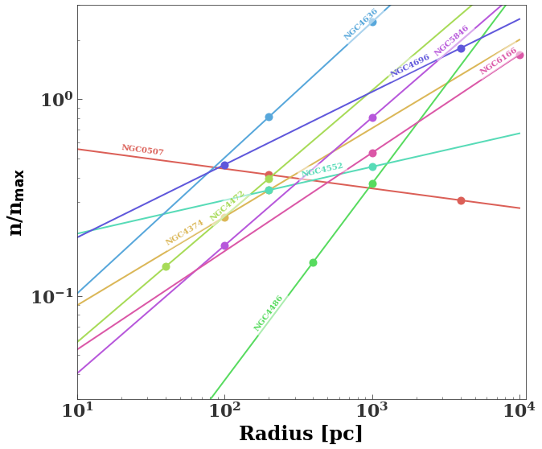

```python
from astropy.io import ascii
import cgs_const as cgs
from scipy.interpolate import InterpolatedUnivariateSpline as IUS
# import brewer2mpl
import seaborn.apionly as sns
import labelLine
%pylab inline

# cols=brewer2mpl.get_map('Set3', 'Qualitative', 9).mpl_colors
cols=sns.color_palette("hls", 9)
##Auxillary mathematical functions for integration and interpolation
def log_interp(x, xs, ys, **kwargs):
    return np.exp(IUS(np.log(xs),np.log(ys), **kwargs)(np.log(x)))

def n_max(r, sig100):
    return 5.*(r/1.0e18)**-1.*(sig100)**4.4

allen_dat=ascii.read('/home/aleksey/Documents/Papers/Allen/data2.csv',\
                    delimiter=',')
##Temperatures in Kelvin
allen_dat['kT']=allen_dat['kT']*1.0e3*cgs.eV/cgs.kb
##Logarithmic grid of radii from 10 to 1000 pc.
rs=np.logspace(1., 4.)
##Fit to the gas density
ns_fit=[allen_dat[i]['ne']*(rs/10.**allen_dat[i]['log(ra)'])**(allen_dat[i]['alpha']) for i in range(len(allen_dat))]
ns_fit=np.array(ns_fit)
##Maximum gas density based on tcool = tadv...
ns_max=[n_max(rs*cgs.pc, 10.**(allen_dat[i]['log(sig)']-2)) for i in range(len(allen_dat))]
ns_max=np.array(ns_max)

fig,ax=plt.subplots(figsize=(10,9))
ax.set_xlabel('Radius [pc]')
ax.set_ylabel(r'$n/n_{\rm max}$')
ax.set_ylim(0.03, 3)
ax.set_xlim(10, 1.1e4)

ls=[]
for i in range(len(allen_dat)):
    l1,=ax.loglog(rs, ns_fit[i]/ns_max[i], color=cols[i], label=allen_dat[i]['Name'])
    nin=log_interp(allen_dat[i]['rin']*1.0e3, rs, ns_fit[i]/ns_max[i])
    ax.loglog(allen_dat[i]['rin']*1.0e3, nin, 'o', color=l1.get_color())
    nout=log_interp(allen_dat[i]['rout']*1.0e3, rs, ns_fit[i]/ns_max[i])
    ax.loglog(allen_dat[i]['rout']*1.0e3, nout, 'o', color=l1.get_color())
    ls.append(l1)

labelLine.labelLines(ls, y_offset=1.1)
```

Slope of the measured density profile vs. Nuker gamma. Note that the Allen galaxies are all massive core ellipticals (the range of gamma is very narrow).

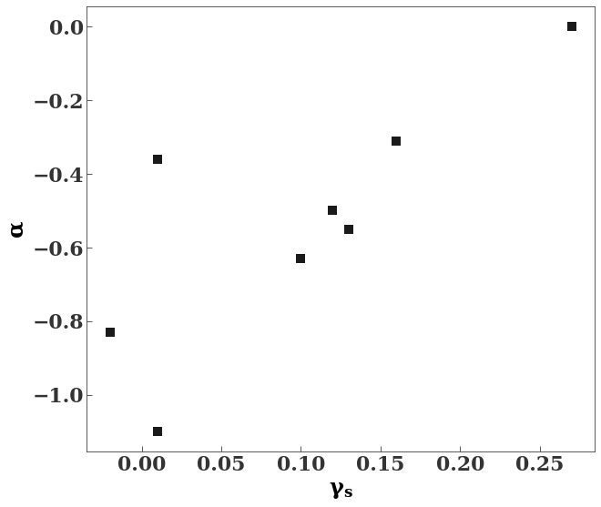

```python
fig,ax=plt.subplots(figsize=(10,9))
ax.set_xlabel(r'$\gamma_s$')
ax.set_ylabel(r'$\alpha$')

plot(allen_dat['gamma_s'], allen_dat['alpha'], 's')
```

Ratio of the gas temperature in Allen Galaxy (evaluated at the Bondi radius) to virial temperature $\left(\frac{\mu m_p \sigma^2}{\gamma k_b}\right)$, where $\gamma=5/3$ is the adiabatic index and $\mu=0.62$ is the mean molecular weight

Temperatures from X-ray spectroscopy in Allen galaxies agree within a factor of order unity with the virial temperature(!)

```python
import cgs_const as cgs
from astropy.table import hstack,Table

gamma=5./3.
mu=0.62

T2=cgs.mp*mu/(gamma*cgs.kb)*(10.**(allen_dat['log(sig)'])*1.0e5)**2.
allen_dat['kT']/T2

hstack([Table([allen_dat['Name']]), Table([allen_dat['kT']/T2],names=['Ratio'])])
```

<Table masked=True length=9>

| Name str7 | Ratio float64 |
| --- | --- |
| NGC0507 | 1.92309796375 |
| NGC4374 | 2.07027499646 |
| NGC4472 | 1.90488046619 |
| NGC4486 | 1.58438118097 |
| NGC4552 | 2.6112261781 |
| NGC4636 | 3.21487023765 |
| NGC4696 | 3.04266898199 |
| NGC5846 | 2.5400630154 |
| NGC6166 | 3.409675434 |